# Tracking Copilot usage segments over time with **vivainsights** in R

2026-07-01

# Copilot usage segments over time

## Introduction

When measuring Copilot adoption, a single snapshot (“what share of people used Copilot last week?”) can be misleading, because usage is a *habit* that builds up (or decays) over many weeks. The **vivainsights** package ships a function, `identify_usage_segments()`, that classifies every person-week into an adoption segment (**Power User**, **Habitual User**, **Novice User**, **Low User** or **Non-user**) using a rolling window of Copilot actions.

This notebook shows how to:

1. build a total Copilot-actions metric from the individual Copilot action columns in a Person Query,
2. classify each person-week with `identify_usage_segments(version = "12w")`, and
3. visualise how the **mix of segments evolves over time** with a stacked-area chart, alongside the trend in average Copilot actions.

We use the built-in `pq_data` sample so the notebook runs end-to-end with no external files. To run this on your own data, replace the `pq_data` load with `vivainsights::import_query("your-person-query.csv")`.

## Set-up

```r
knitr::opts_chunk$set(warning = FALSE, message = FALSE)
library(dplyr)
library(tidyr)
library(ggplot2)
library(scales)
library(vivainsights)
```

For clarity in this demonstration we use the explicit `package::function()` notation in a few places to show which package each function comes from.

## Load data and build a total Copilot-actions metric

`identify_usage_segments()` expects a single metric column that captures Copilot intensity. A Person Query splits Copilot activity across several `Copilot_actions_taken_in_*` columns (Teams, Outlook, Word, Excel, and so on), so we sum them into a single `Total_Copilot_actions_taken` column. We also replace missing values with `0`, because a missing action count means the person simply did not take that action that week.

```r
data("pq_data", package = "vivainsights")

app_cols <- grep("^Copilot_actions_taken_in", names(pq_data), value = TRUE)
app_cols
```

```
## [1] "Copilot_actions_taken_in_Teams"
## [2] "Copilot_actions_taken_in_Copilot_chat__work_"
## [3] "Copilot_actions_taken_in_Excel"
## [4] "Copilot_actions_taken_in_Outlook"
## [5] "Copilot_actions_taken_in_Powerpoint"
## [6] "Copilot_actions_taken_in_Word"
```

```r
pq <- pq_data %>%
  mutate(across(all_of(app_cols), ~ tidyr::replace_na(.x, 0))) %>%
  mutate(Total_Copilot_actions_taken = rowSums(across(all_of(app_cols))))

# A quick look at the panel structure
pq %>%
  summarise(
    persons = dplyr::n_distinct(PersonId),
    weeks   = dplyr::n_distinct(MetricDate),
    from    = min(MetricDate),
    to      = max(MetricDate)
  )
```

```
## # A tibble: 1 × 4
##   persons weeks from       to
##     <int> <int> <date>     <date>
## 1     300    23 2024-04-28 2024-09-29
```

## Classify each person-week into a usage segment

`identify_usage_segments()` with `version = "12w"` applies the standard 12-week rolling definition: a person’s segment in a given week depends on their Copilot actions over that week and the preceding weeks. Returning `return = "data"` appends the classification columns to the input frame.

```r
seg <- vivainsights::identify_usage_segments(
  data    = pq,
  metric  = "Total_Copilot_actions_taken",
  version = "12w",
  return  = "data"
)

seg <- seg %>%
  mutate(UsageSegments_12w = factor(
    UsageSegments_12w,
    levels = c("Power User", "Habitual User", "Novice User",
               "Low User", "Non-user")
  ))

# Overall distribution of person-weeks across segments
seg %>%
  count(UsageSegments_12w) %>%
  mutate(share = scales::percent(n / sum(n), accuracy = 0.1))
```

```
## # A tibble: 4 × 3
##   UsageSegments_12w     n share
##   <fct>             <int> <chr>
## 1 Power User            7 0.1%
## 2 Habitual User      4479 64.9%
## 3 Novice User        2411 34.9%
## 4 Non-user              3 0.0%
```

> **Note on the rolling window.** Because the 12-week version looks back up to 12 weeks, the earliest weeks in any export are based on a shorter window and are therefore less stable. When you have a long enough history, it is common to drop the first ~12 weeks before interpreting the trend. With the short sample here we keep all weeks but flag the caveat.

## Segment mix over time (stacked area)

The clearest way to show adoption momentum is the **share of the population in each segment, week by week**. A stacked-area chart makes the shift from lighter to heavier usage (or vice versa) easy to read.

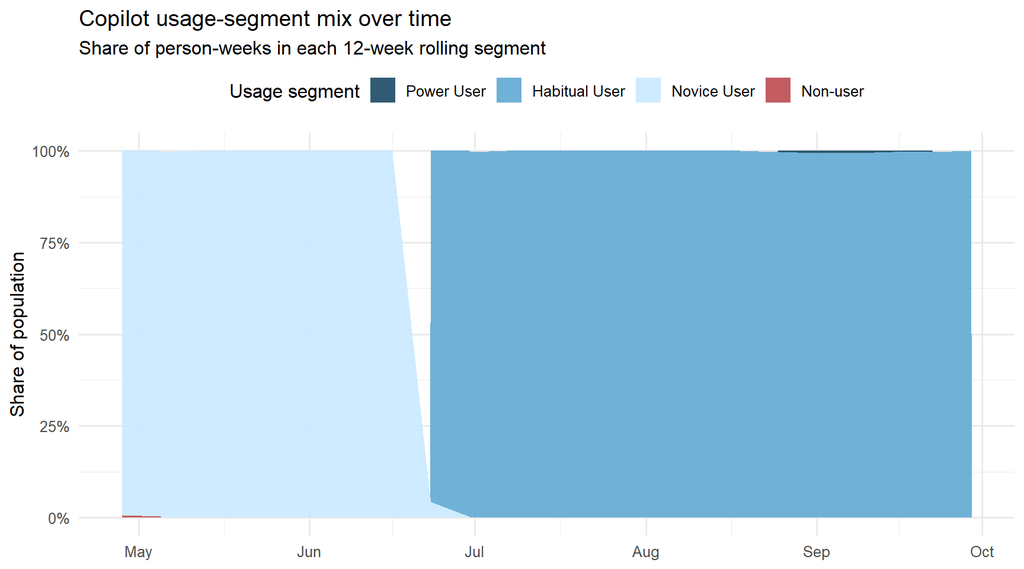

```r
seg_share <- seg %>%
  count(MetricDate, UsageSegments_12w, name = "n") %>%
  group_by(MetricDate) %>%
  mutate(share = n / sum(n)) %>%
  ungroup()

seg_palette <- c(
  "Power User"    = "#1b4965",
  "Habitual User" = "#5fa8d3",
  "Novice User"   = "#cae9ff",
  "Low User"      = "#f4a259",
  "Non-user"      = "#bc4b51"
)

ggplot(seg_share, aes(x = MetricDate, y = share, fill = UsageSegments_12w)) +
  geom_area(alpha = 0.9) +
  scale_y_continuous(labels = scales::percent) +
  scale_fill_manual(values = seg_palette, name = "Usage segment") +
  labs(
    title    = "Copilot usage-segment mix over time",
    subtitle = "Share of person-weeks in each 12-week rolling segment",
    x = NULL, y = "Share of population"
  ) +
  theme_minimal(base_size = 12) +
  theme(legend.position = "top")
```

## Average Copilot actions over time

Alongside the segment mix, it is useful to plot the trend in mean Copilot actions per person-week. Rising average actions with a growing Power/Habitual share is the signature of healthy adoption.

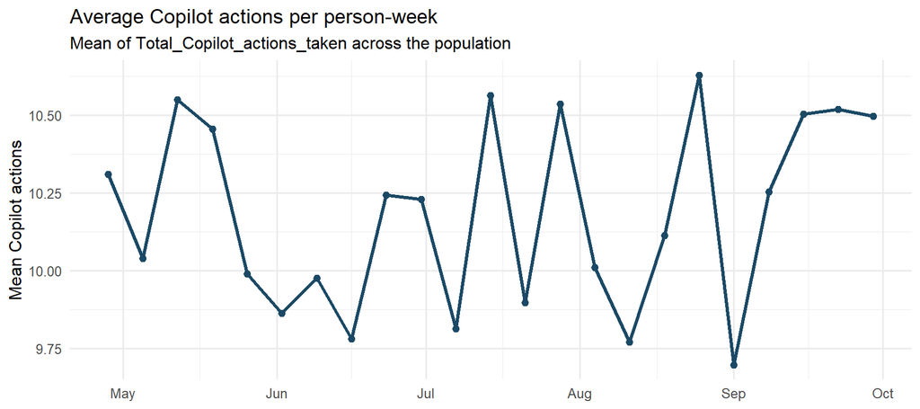

```r
actions_trend <- seg %>%
  group_by(MetricDate) %>%
  summarise(mean_actions = mean(Total_Copilot_actions_taken, na.rm = TRUE),
            .groups = "drop")

ggplot(actions_trend, aes(x = MetricDate, y = mean_actions)) +
  geom_line(linewidth = 1.1, colour = "#1b4965") +
  geom_point(size = 2, colour = "#1b4965") +
  labs(
    title    = "Average Copilot actions per person-week",
    subtitle = "Mean of Total_Copilot_actions_taken across the population",
    x = NULL, y = "Mean Copilot actions"
  ) +
  theme_minimal(base_size = 12)
```

## Wrapping up

With three short steps, namely summing the Copilot action columns, calling `identify_usage_segments(version = "12w")`, and aggregating by `MetricDate`, we turned a raw Person Query into a longitudinal view of Copilot adoption. The same code runs unchanged on a real export loaded with `vivainsights::import_query()`; just point it at your own file. Remember to treat the earliest weeks with caution because of the 12-week warm-up window.